# All Cause Minus COVID

This contains all code used to analyze the datasets found in the `/CleanData` directory, which were previously generated in the `/Scripts/Cleaning.rmd` file.

# 1 Introduction

This analysis will replicate the May 2021 ARIMA, this time altering the all-cause death data to exclude deaths due to COVID, as they had a colinear increase over the same time period.

# 2 Descriptive Statistics

We will start by comparing the all-cause deaths over the time period with the all-cause deaths minus the ones attributable to covid.

```r
all_cause <- read.csv("../CleanData/all_cause_repro_f.csv")
all_cause.ts <- all_cause %>%
  mutate(month_year = ymd(month_year),
         month = yearmonth(month_year)) %>%
  as_tsibble(index = month)

glimpse(all_cause.ts)
```

```
## Rows: 72
## Columns: 5
## $ Deaths     <int> 436, 378, 354, 336, 380, 355, 384, 360, 371, 363, 371, 378,…
## $ month_year <date> 2018-01-01, 2018-02-01, 2018-03-01, 2018-04-01, 2018-05-01…
## $ bill8      <lgl> FALSE, FALSE, FALSE, FALSE, FALSE, FALSE, FALSE, FALSE, FAL…
## $ time       <int> 1, 2, 3, 4, 5, 6, 7, 8, 9, 10, 11, 12, 13, 14, 15, 16, 17, …
## $ month      <mth> 2018 Jan, 2018 Feb, 2018 Mar, 2018 Apr, 2018 May, 2018 Jun,…
```

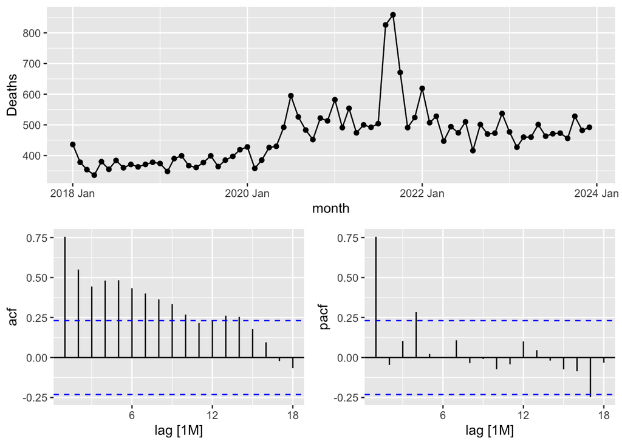

```r
all_cause.ts|>
  gg_tsdisplay(y = Deaths, plot_type = "partial")
```

```r
all_minus_covid <- read.csv("../CleanData/all_cause_minus_covid.csv")

all_minus_covid.ts <- all_minus_covid %>%
  mutate(month_year = ymd(month_year),
         month = yearmonth(month_year),
         time = row_number()) %>%
  as_tsibble(index = month)

glimpse(all_minus_covid.ts)
```

```
## Rows: 72
## Columns: 4
## $ month_year <date> 2018-01-01, 2018-02-01, 2018-03-01, 2018-04-01, 2018-05-01…
## $ Deaths     <int> 436, 378, 354, 336, 380, 355, 384, 360, 371, 363, 371, 378,…
## $ month      <mth> 2018 Jan, 2018 Feb, 2018 Mar, 2018 Apr, 2018 May, 2018 Jun,…
## $ time       <int> 1, 2, 3, 4, 5, 6, 7, 8, 9, 10, 11, 12, 13, 14, 15, 16, 17, …
```

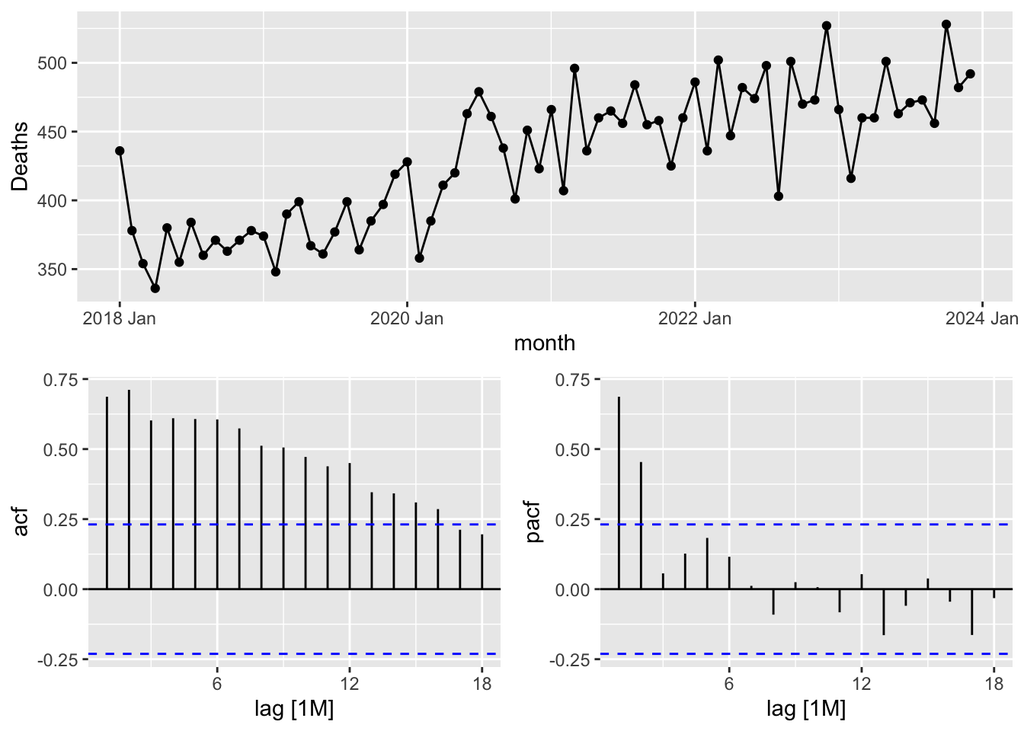

```r
all_minus_covid.ts |>
  gg_tsdisplay(y = Deaths, plot_type = "partial")
```

Looking at these graphs, it is pretty clear that once we remove COVID-attributable deaths, we see a very different picture: it looks like over the study period, all-cause deaths are generally increasing over time, with no observable outliers.

We will continue with fitting an arima, though it is almost guaranteed that all the values forecasted will be completely expected.

```r
report(all_minus_covid.arima)
```

```
## Series: Deaths
## Model: LM w/ ARIMA(1,0,1) errors
##
## Coefficients:
##          ar1      ma1     step    ramp  intercept
##       0.9498  -0.7367  21.1245  1.6957   405.6960
## s.e.  0.0511   0.0923  21.5204  1.1512    18.2163
##
## sigma^2 estimated as 919.5:  log likelihood=-345.58
## AIC=703.16   AICc=704.45   BIC=716.82
```

```r
#Modeling counterfactual
counterfactual <- all_minus_covid.ts %>%
  filter(month_year < "2021-05-01") %>%
  model(
    arima_null = ARIMA(
      Deaths,
      stepwise = FALSE
    )
  )
report(counterfactual)
```

```
## Series: Deaths
## Model: ARIMA(0,1,1)
##
## Coefficients:
##           ma1
##       -0.6669
## s.e.   0.1277
##
## sigma^2 estimated as 889:  log likelihood=-187.53
## AIC=379.07   AICc=379.4   BIC=382.39
```

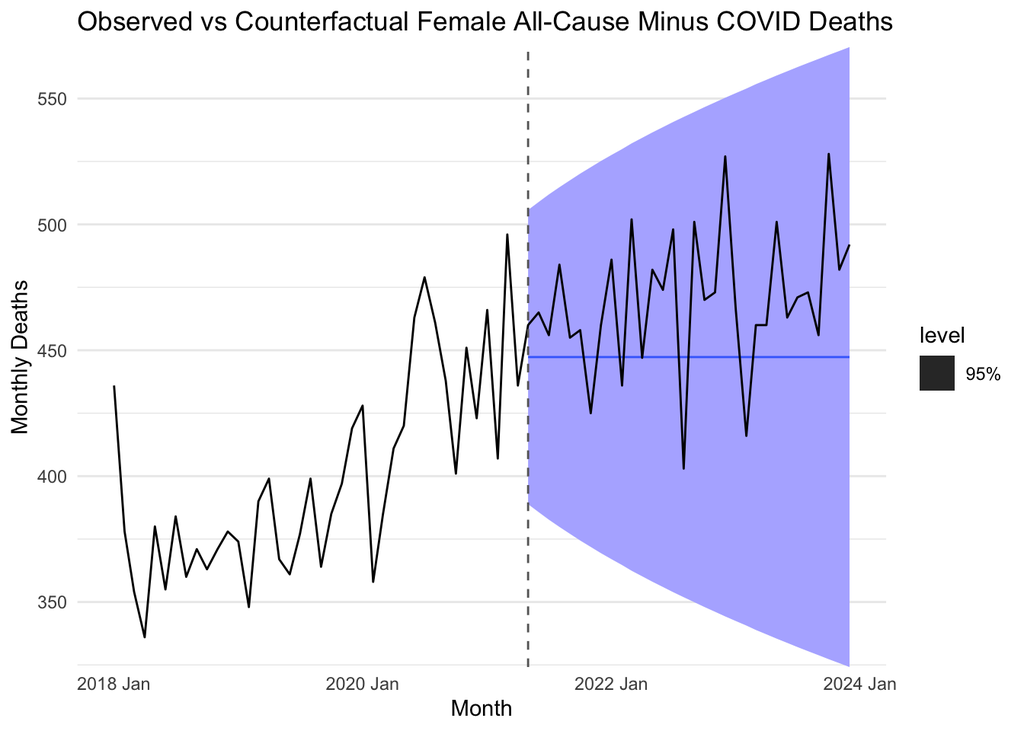

```r
#forecast into post-intervention period
fc_counterfactual <- counterfactual %>%
  forecast(h = 28+4)

 autoplot(fc_counterfactual, all_minus_covid.ts, level = 95) +
  geom_vline(
    xintercept = as.numeric(as_date(make_yearmonth(2021, 5))),
    linetype = "dashed",
    color = "grey40"
  ) +
  labs(
    title = "Observed vs Counterfactual Female All-Cause Minus COVID Deaths",
    y = "Monthly Deaths",
    x = "Month"
  ) +
  scale_y_continuous(expand = c(0, 0)) +
  theme_minimal() +
  theme(
    panel.grid.major.x = element_blank(),
    panel.grid.minor.x = element_blank()
  )
```

# 3 Racial Disag

Comparing all cause and all cause minus covid:

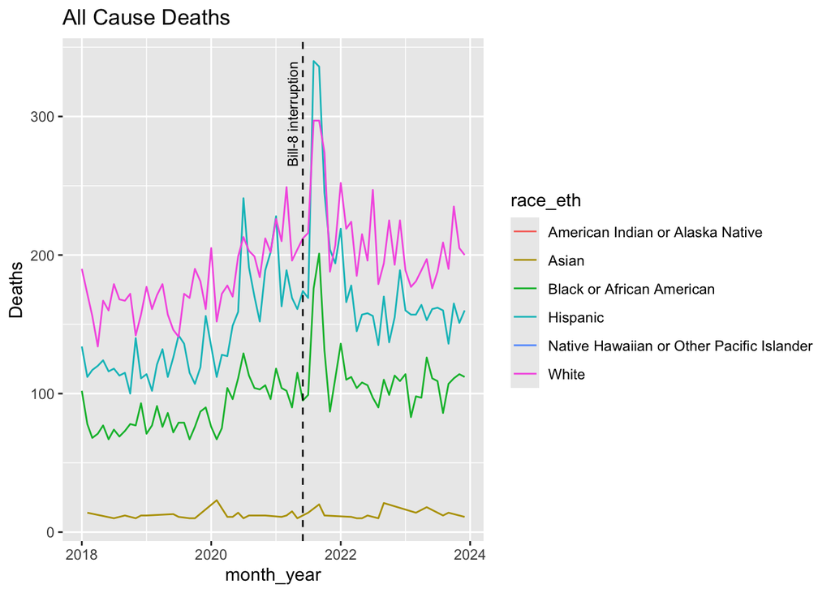

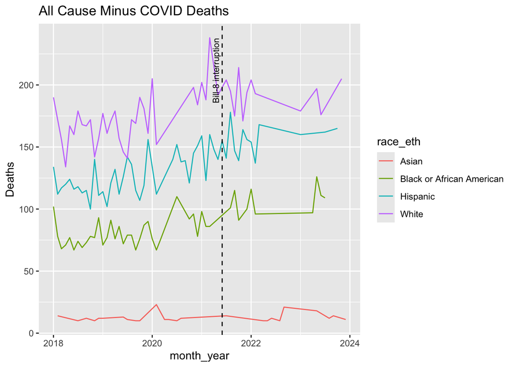

Once again, a lot of the relationship we previously saw is now missing.

Let’s also check and see how much data is missing:

```r
range(racial_covid$Deaths)
```

```
## [1]  10 238
```

```r
racial_covid %>%
  group_by(race_eth) %>%
  summarize(
    missing_count = sum(is.na(Deaths)),
    .groups = "drop"
  )
```

```
## # A tibble: 4 × 2
##   race_eth                  missing_count
##   <chr>                             <int>
## 1 Asian                                 0
## 2 Black or African American             0
## 3 Hispanic                              0
## 4 White                                 0
```

# 4 ARIMA Analysis

We run into a problem here…. there are implicit gaps in time for each of the racial groups. The only way to get around this is to use `tsibble::fill_gaps()`, which goes against CDC rules. For exploration sake, we are going to proceed with that, but this is probably unusable.

## 4.1 Hispanic

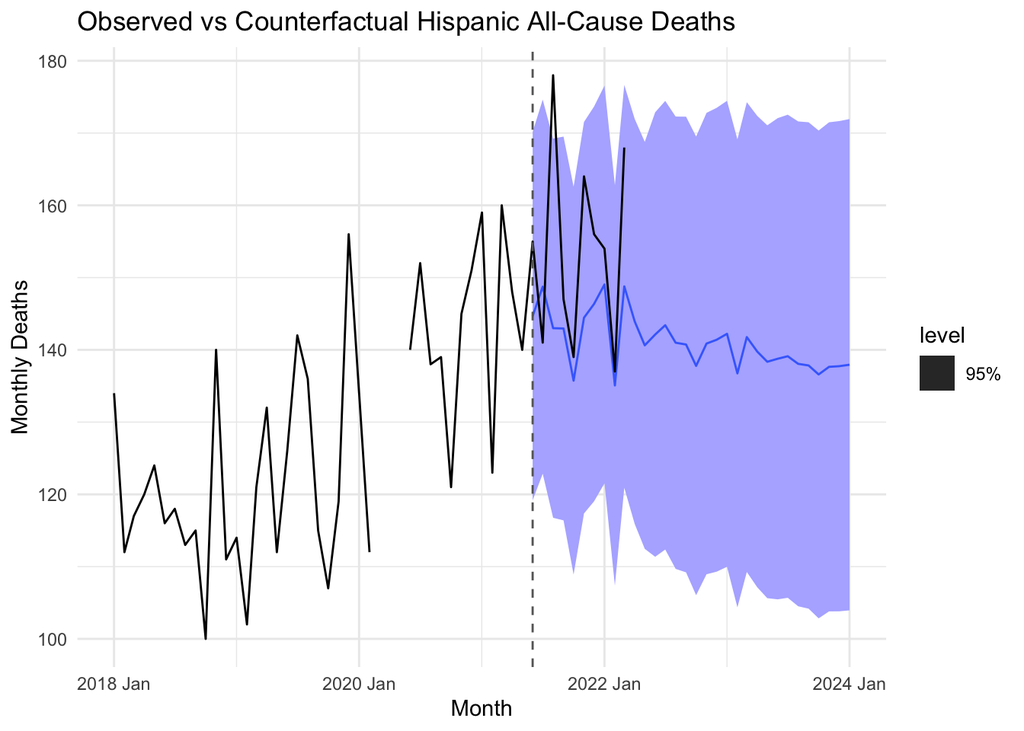

```r
hispanic <- racial_covid %>%
  filter(race_eth == "Hispanic") %>%
  arrange(month_year) %>%
  mutate(time = row_number())

monthly.ts <- prepare_ts_df_fill_gaps(hispanic)
monthly.ts <- create_intervention(monthly.ts, "2021-06-01")

m_arima <- fit_arima(monthly.ts)

fc_m <- counterfactual_forecast(monthly.ts, "2021-06-01", 32)

plot_counterfactual(
  fc_m,
  monthly.ts,
  "2021-06-01",
  "Observed vs Counterfactual Hispanic All-Cause Deaths"
)
```

## 4.2 Non-Hispanic White

Won’t run, we’re missing the intervention date.

```r
white  <- racial_covid %>%
  filter(race_eth == "White") %>%
  arrange(month_year) %>%
  mutate(time = row_number())

monthly.ts <- prepare_ts_df_fill_gaps(white)
monthly.ts <- create_intervention(monthly.ts, "2021-06-01")

m_arima <- fit_arima(monthly.ts)

fc_m <- counterfactual_forecast(monthly.ts, "2021-06-01", 32)

plot_counterfactual(
  fc_m,
  monthly.ts,
  "2021-06-01",
  "Observed vs Counterfactual White All-Cause Deaths"
)
```

## 4.3 Non-Hispanic Black

This one also doesn’t have the intervention date in data! Big bummer.

```r
black <-  racial_covid %>%
  filter(race_eth == "Black or African American") %>%
  arrange(month_year) %>%
  mutate(time = row_number())

monthly.ts <- prepare_ts_df_fill_gaps(black)
monthly.ts <- create_intervention(monthly.ts, "2021-06-01")

m_arima <- fit_arima(monthly.ts)

fc_m <- counterfactual_forecast(monthly.ts, "2021-06-01", 32)

plot_counterfactual(
  fc_m,
  monthly.ts,
  "2021-06-01",
  "Observed vs Counterfactual Black All-Cause Deaths"
)
```